# The percentage of an student based on the no. of study hours.

Linear Regression involving two variables using Python.

Simple Linear Regression In this regression, we will predict the percentage of marks of students based on the numbers of study hours.

```python
#importing all the required libraries
import numpy as np
import pandas as pd
import matplotlib.pyplot as mt
%matplotlib inline
```

```python
#reading the data
link='http://bit.ly/w-data'
data=pd.read_csv(link)
data.head(25)
```

|  | Hours | Scores |
| --- | --- | --- |
| 0 | 2.5 | 21 |
| 1 | 5.1 | 47 |
| 2 | 3.2 | 27 |
| 3 | 8.5 | 75 |
| 4 | 3.5 | 30 |
| 5 | 1.5 | 20 |
| 6 | 9.2 | 88 |
| 7 | 5.5 | 60 |
| 8 | 8.3 | 81 |
| 9 | 2.7 | 25 |
| 10 | 7.7 | 85 |
| 11 | 5.9 | 62 |
| 12 | 4.5 | 41 |
| 13 | 3.3 | 42 |
| 14 | 1.1 | 17 |
| 15 | 8.9 | 95 |
| 16 | 2.5 | 30 |
| 17 | 1.9 | 24 |
| 18 | 6.1 | 67 |
| 19 | 7.4 | 69 |
| 20 | 2.7 | 30 |
| 21 | 4.8 | 54 |
| 22 | 3.8 | 35 |
| 23 | 6.9 | 76 |
| 24 | 7.8 | 86 |

Now we will be ploting our data points in 2D graph to find any relationship between the data.

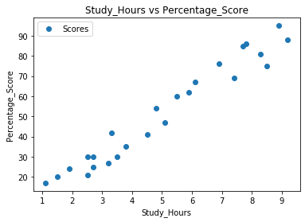

```python
data.plot(x="Hours", y="Scores", style="o")
mt.title("Study_Hours vs Percentage_Score")
mt.xlabel("Study_Hours")
mt.ylabel("Percentage_Score")
mt.show()
```

From the above graph, we can conclude that there is positive relation between the number of hours studies and percentage of score. Now dividing the data into attributes and lables.

```python
X=data.iloc[:,:-1].values
y=data.iloc[:,1].values
```

In the next step, we will use Scikit-Learn's built-in train_set_split() method to split our data into training and test sets.

```python
from sklearn.model_selection import train_test_split
X_train,X_test,y_train,y_test=train_test_split(X,y,test_size=0.2,random_state=0)
```

# Training the Algorithm

```python
from sklearn.linear_model import LinearRegression
R1=LinearRegression()
R1.fit(X,y)
print("Training the model")
```

```
Training the model
```

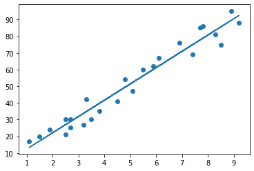

```python
#plotting regression line
line=R1.coef_*X+R1.intercept_
mt.scatter(X,y)
mt.plot(X,line)
mt.show()
```

# Predictions

```python
#testing data
print(X_test)
y_pred=R1.predict(X_test)
```

```
[[1.5]
 [3.2]
 [7.4]
 [2.5]
 [5.9]]
```

```python
#comparing actual vs predicted
df=pd.DataFrame({"Actual":y_test, "Predicted":y_pred})
df
```

|  | Actual | Predicted |
| --- | --- | --- |
| 0 | 20 | 17.147378 |
| 1 | 27 | 33.766244 |
| 2 | 69 | 74.824618 |
| 3 | 30 | 26.923182 |
| 4 | 62 | 60.160913 |

```python
print("Training Score:",R1.score(X_train,y_train))
print("Testing Score: ",R1.score(X_test,y_test))
```

```
Training Score: 0.9512837351709387
Testing Score:  0.9491748734859171
```

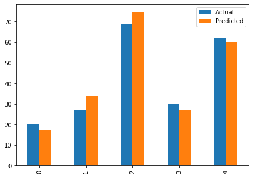

```python
#plotting the actual and predicted value into bar graph
df.plot(kind="bar", figsize=(7,5))
mt.show()
```

```python
#predicting for 9.25 hrs per day
hours=9.25
test=np.array([hours])
test=test.reshape(-1,1)
pred_val=R1.predict(test)
print("No. of hours=", hours)
print("Predicted Score=", pred_val[0])
```

```
No. of hours= 9.25
Predicted Score= 92.90985477015731
```

# Evaluating the Model

```python
import numpy as np
from sklearn import metrics
print("Mean Absolute Error: ",metrics.mean_absolute_error(y_test,y_pred))
print("Mean Squared Error: ",metrics.mean_squared_error(y_test,y_pred))
print("Root Mean Sqaured Error: ",np.sqrt(metrics.mean_squared_error(y_test,y_pred)))
print("Explained Variance Score: ",metrics.explained_variance_score(y_test,y_pred))
```

```
Mean Absolute Error:  4.071877793635608
Mean Squared Error:  20.1389481299402
Root Mean Sqaured Error:  4.487643939746134
Explained Variance Score:  0.951522433518808
```

The above step of calculating error is to evaluate the performance of algorithm. And its is important as it tells how it differently perform on different dataset.